# Querying a Google BigQuery database

Pablo Barbera and Akitaka Matsuo

27 November, 2018

We will now continue practicing how to write SQL queries using a Google BigQuery. There are a number of public databases available for testing ([link](https://bigquery.cloud.google.com/welcome/sharp-harbor-223622)). We will use two of such public databases.

## London LSOA Crime statistics

https://bigquery.cloud.google.com/table/bigquery-public-data:london_crime.crime_by_lsoa These data count the number of crimes at two different geographic levels of London (LSOA and borough) by year, according to crime type.

First, go to the above link, log into your Google account, and either click on “Create a Project” or pick an existing project. You may need to tie the London crime data to your project again in case it does not apear. Use your project id instead of “my472-bigquery-261216” in the code below.

```r
library(bigrquery)
project <- "my472-bigquery-261216"

get_table(project="bigquery-public-data",
          dataset="london_crime",
          table="crime_by_lsoa")
```

```
## Using an auto-discovered, cached token.
## To suppress this message, modify your code or options to clearly consent to the use of a cached token.
## See gargle's "Non-interactive auth" vignette for more details:
## https://gargle.r-lib.org/articles/non-interactive-auth.html
## The bigrquery package is using a cached token for milenavenelinova@gmail.com.
```

[output not shown]

[output cut: 93 more lines]

```
##
## $numRows
## [1] "13490604"
##
## $creationTime
## [1] "1495719451969"
##
## $lastModifiedTime
## [1] "1502204511203"
##
## $type
## [1] "TABLE"
##
## $location
## [1] "EU"
```

1. First, connect to the database and count how many rows it contains:

```r
query_exec("SELECT COUNT(*) FROM [bigquery-public-data:london_crime.crime_by_lsoa]",
           project = project, useLegacySql = TRUE)
```

```
## 0 bytes processed
```

```
##        f0_
## 1 13490604
```

2. Crime by year

```r
query_exec("SELECT year, SUM(value) AS count_crime FROM
           [bigquery-public-data:london_crime.crime_by_lsoa]
           GROUP BY year
           ORDER BY year",
           project = project)
```

```
## 0 bytes processed
```

```
##   year count_crime
## 1 2008      738641
## 2 2009      717214
## 3 2010      715324
## 4 2011      724915
## 5 2012      737329
## 6 2013      686407
## 7 2014      680183
## 8 2015      711624
## 9 2016      736121
```

3. Crime by borough and year

```r
dat <- query_exec("SELECT year, borough, SUM(value) AS count_crime FROM
           [bigquery-public-data:london_crime.crime_by_lsoa]
           GROUP BY year, borough",
           project = project)
```

```
## 0 bytes processed
```

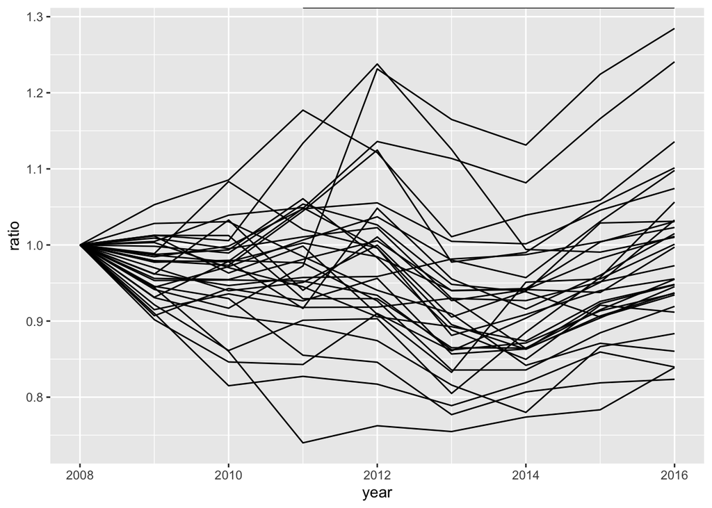

```r
View(dat)
library(ggplot2)
library(tidyverse)
dat %>% group_by(borough) %>%
  mutate(ratio = count_crime/count_crime[year == 2008]) %>%
ggplot(aes(x = year, y = ratio, group = borough)) + geom_line()
```

4. Crime by year and category

```r
dat_3 <- query_exec("SELECT year, major_category, SUM(value) AS count_crime FROM
           [bigquery-public-data:london_crime.crime_by_lsoa]
           GROUP BY year, major_category",
           project = project)
```

```
## 0 bytes processed
```

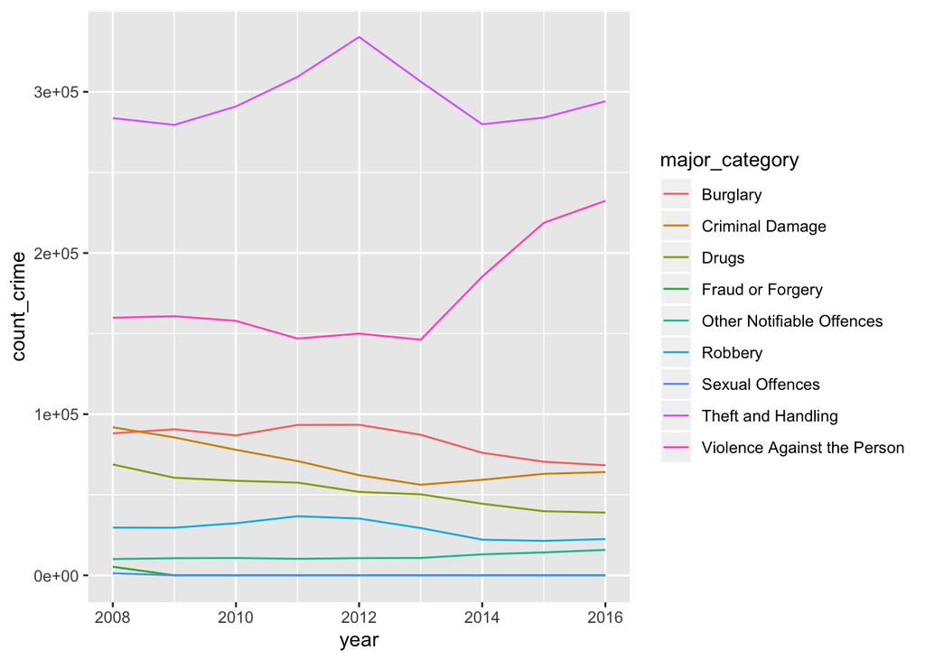

```r
View(dat_3)
ggplot(dat_3) + aes(x = year, y = count_crime, group = major_category,
                    colour = major_category) + geom_line()
```

5. Map?

```r
require(rgdal)
```

```r
require(ggplot2)

dat_lsoa <- query_exec("SELECT lsoa_code, SUM(value) AS count_crime FROM
           [bigquery-public-data:london_crime.crime_by_lsoa]
           GROUP BY lsoa_code",
           project = project)
```

```
## 0 bytes processed
```

```r
View(dat_lsoa)


# shapefile is from: https://data.london.gov.uk/dataset/statistical-gis-boundary-files-london
shp <- readOGR(dsn = "~/Downloads/statistical-gis-boundaries-london/ESRI/LSOA_2011_London_gen_MHW.shp", stringsAsFactors = F)
shp@data <- shp@data %>%
  mutate(id = rownames(shp@data)) %>%
  merge(dat_lsoa, by.x = "LSOA11CD", by.y = "lsoa_code")

shp_fort <- fortify(shp) %>%
  merge(shp@data, by = 'id')
```

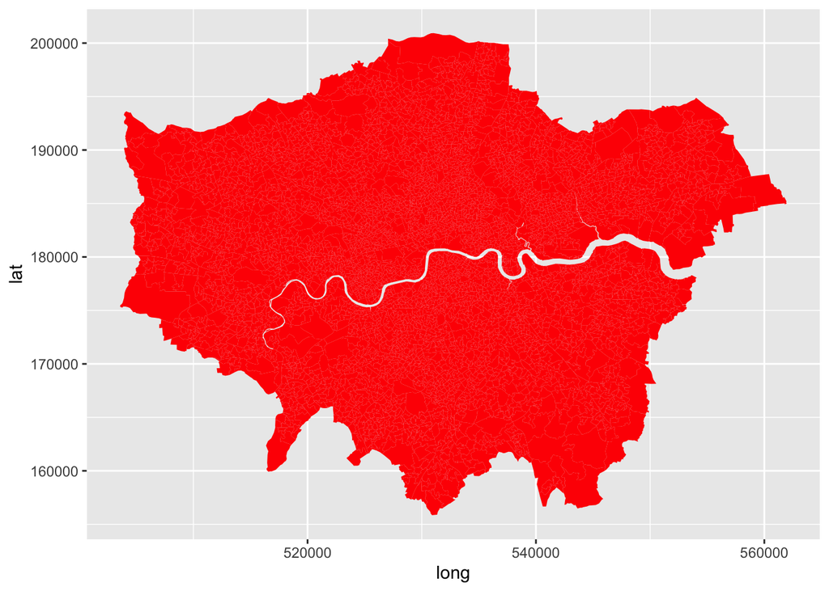

```r
map <- ggplot() + geom_polygon(data = shp_fort, aes(x = long, y = lat, group = group), colour = NA, fill = "red")
map
```

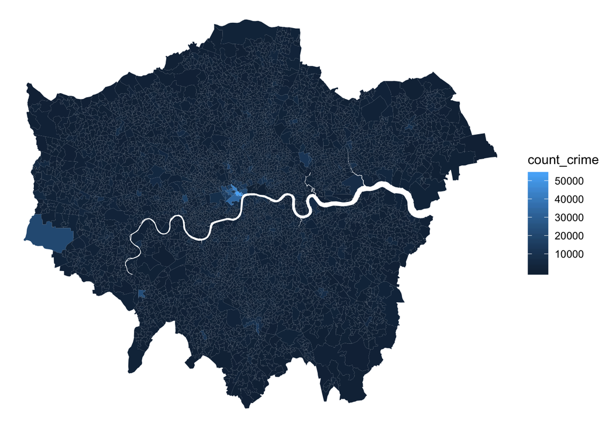

```r
map <- ggplot() + geom_polygon(data = shp_fort, aes(x = long, y = lat, group = group,
                                               fill = count_crime), colour = NA)
map + theme_void()
```

## NYC Bicycle Hire

The second database is the one that contains all Citi Bike trips (NYC’s bike-sharing service) since Citi Bike launched in September 2013.

1. First, connect to the database and count how many rows it contains:

```r
get_table(project="bigquery-public-data",
          dataset="new_york",
          table="citibike_trips")
```

[output not shown]

[output cut: 202 more lines]

```
##
## $numRows
## [1] "33319019"
##
## $creationTime
## [1] "1480379234895"
##
## $lastModifiedTime
## [1] "1502204173119"
##
## $type
## [1] "TABLE"
##
## $location
## [1] "US"
```

```r
# how many trips in the database?
query_exec(
  "SELECT COUNT(*) FROM [bigquery-public-data:new_york.citibike_trips]",
    project = project)
```

```
## 0 bytes processed
```

```
##        f0_
## 1 33319019
```

```r
# see the first 10 entries
query_exec(
  "SELECT *
  FROM [bigquery-public-data:new_york.citibike_trips]
  LIMIT 10",
    project = project)
```

```
## 0 bytes processed
```

```
##    tripduration           starttime            stoptime start_station_id
## 1           783 2016-06-10 22:47:47 2016-06-10 23:00:51             3122
## 2          1093 2016-05-13 07:19:22 2016-05-13 07:37:36             3122
## 3          2582 2016-09-11 10:26:43 2016-09-11 11:09:46             3122
## 4          2234 2016-09-08 23:06:51 2016-09-08 23:44:06             3122
## 5          5129 2015-12-31 14:01:44 2015-12-31 15:27:13             3122
## 6          1099 2016-06-06 22:39:33 2016-06-06 22:57:52             3122
## 7          1229 2016-09-25 15:35:28 2016-09-25 15:55:58             3122
## 8           892 2016-09-27 17:57:13 2016-09-27 18:12:06             3122
## 9           720 2016-09-17 09:58:34 2016-09-17 10:10:35             3122
## 10          377 2016-09-27 07:12:36 2016-09-27 07:18:53             3122
##    start_station_name start_station_latitude start_station_longitude
## 1       48 Ave & 5 St               40.74436               -73.95587
## 2       48 Ave & 5 St               40.74436               -73.95587
## 3       48 Ave & 5 St               40.74436               -73.95587
```

[output cut: 29 more lines]

2. Which are the 10 most popular stations in terms of how many trips started there?

```r
q <- "SELECT start_station_name,
  COUNT(*) AS count_start
  FROM [bigquery-public-data:new_york.citibike_trips]
    GROUP BY start_station_name
  ORDER BY count_start DESC
  LIMIT 10"
query_exec(q, project = project)
```

```
## 0 bytes processed
```

```
##          start_station_name count_start
## 1        E 17 St & Broadway      291615
## 2           8 Ave & W 31 St      291577
## 3     Lafayette St & E 8 St      277060
## 4           W 21 St & 6 Ave      275348
## 5     West St & Chambers St      260911
## 6     Pershing Square North      246181
## 7        Broadway & E 14 St      244420
## 8        Broadway & E 22 St      237394
## 9  Cleveland Pl & Spring St      229694
## 10          8 Ave & W 33 St      223970
```

3. What is the average trip duration based on the hour of the day when they start?

```r
query_exec(
  "SELECT HOUR(starttime) AS hour_of_day,
    AVG( (stoptime-starttime)/1000000/60 ) AS duration_minutes
  FROM [bigquery-public-data:new_york.citibike_trips]
  GROUP BY hour_of_day
  ORDER BY hour_of_day",
  project = project
)
```

```
## 0 bytes processed
```

```
##    hour_of_day duration_minutes
## 1            0         15.43474
## 2            1         17.30161
## 3            2         17.52486
## 4            3         17.26372
## 5            4         16.18904
## 6            5         12.26975
## 7            6         11.68007
## 8            7         12.59374
## 9            8         13.42177
## 10           9         13.99235
## 11          10         16.04965
## 12          11         17.22475
## 13          12         16.66324
## 14          13         16.96284
## 15          14         17.15015
## 16          15         17.10357
## 17          16         16.61499
## 18          17         15.77430
## 19          18         15.53041
## 20          19         15.30051
## 21          20         15.27967
## 22          21         15.32957
## 23          22         15.57605
## 24          23         15.40590
```

4. What is the average trip duration of a CitiBike trip in NYC?

```r
query_exec(
  "SELECT AVG( (stoptime-starttime)/1000000/60 ) AS duration_minutes,
  FROM [bigquery-public-data:new_york.citibike_trips]",
  project = project
)
```

```
## 0 bytes processed
```

```
##   duration_minutes
## 1         15.56699
```

5. What is the average trip duration based on the gender of the riders?

```r
query_exec(
  "SELECT gender,
    AVG( (stoptime-starttime)/1000000/60 ) AS duration_minutes,
    COUNT(*) AS trip_count
  FROM [bigquery-public-data:new_york.citibike_trips]
  GROUP BY gender",
  project = project
)
```

```
## 0 bytes processed
```

```
##    gender duration_minutes trip_count
## 1 unknown         30.93353    4090921
## 2    male         12.84881   22349314
## 3  female         15.25968    6878784
```

6. What is the average distance of a trip?

```r
query_exec(
  "SELECT AVG( (ABS(start_station_latitude-end_station_latitude) +
      ABS(start_station_longitude-end_station_longitude)) * 111) AS avg_distance_km
  FROM [bigquery-public-data:new_york.citibike_trips]",
  project = project
)
```

```
## 0 bytes processed
```

```
##   avg_distance_km
## 1        2.537646
```

7. What is the average distance of a trip based on gender?

```r
query_exec(
  "SELECT gender,
      AVG( (ABS(start_station_latitude-end_station_latitude) +
      ABS(start_station_longitude-end_station_longitude)) * 111) AS avg_distance_km
  FROM [bigquery-public-data:new_york.citibike_trips]
  GROUP BY gender",
  project = project
)
```

```
## 0 bytes processed
```

```
##    gender avg_distance_km
## 1    male        2.485110
## 2 unknown        2.742828
## 3  female        2.586311
```